# Analysis of the City of Toronto Tickets Infractions

**By Mohammad AL-Amar**

*3.1.1 The top 20 ticket infractions by frequency*

Data contains the infaction’s code, description and frequency

```r
#finding the top 20 ticket infractions (frequency)
top_20_frequency
```

| infraction_code | infraction_description | frequency |
| --- | --- | --- |
| 5 | PARK HWY PROHIBED TIME/DAY | 605901 |
| 29 | PARK PROHIBITED TIME NO PERMIT | 453490 |
| 210 | PARK FAIL TO DISPLAY RECEIPT | 348958 |
| 3 | PARK/LEAVE ON PRIVATE PROPERTY | 327854 |
| 207 | PARK FAIL TO DEP. FEE MACHINE | 247095 |
| 9 | STOP HWY PROHIBITED TIME/DAY | 179083 |
| 2 | PARK LONGER THAN 3 HOURS | 131360 |
| 8 | STAND SIGN HWY PRO TIMES/DAYS | 113223 |
| 6 | PARK-HWY EXCESS PERMTD TIME | 89844 |
| 406 | PARK-VEH. W/O VALID ONT PLATE | 87144 |

[output cut: 10 more lines]

*3.1.2 The top 20 ticket infractions by revenue*

Data contains the infaction’s code, description and total revenue

```r
#finding the top 20 ticket infractions (revenue))                   3.1.2
top_20_revenue
```

| infraction_code | infraction_description | revenue |
| --- | --- | --- |
| 5 | PARK HWY PROHIBED TIME/DAY | $ 222616860 |
| 29 | PARK PROHIBITED TIME NO PERMIT | $ 130208640 |
| 3 | PARK/LEAVE ON PRIVATE PROPERTY | $ 112771155 |
| 9 | STOP HWY PROHIBITED TIME/DAY | $ 97262640 |
| 210 | PARK FAIL TO DISPLAY RECEIPT | $ 84734820 |
| 207 | PARK FAIL TO DEP. FEE MACHINE | $ 68154570 |
| 8 | STAND SIGN HWY PRO TIMES/DAYS | $ 63248280 |
| 347 | PARK IN A FIRE ROUTE | $ 58533030 |
| 403 | STOP-SIGNED HIGHWAY-RUSH HOUR | $ 52327500 |
| 15 | PARK 3 M OF FIRE HYDRANT | $ 41104880 |

[output cut: 10 more lines]

```r
# Total revenue generated from all tickets                            3.1.3
total_revenue
```

| total_revenue |
| --- |
| $ 1193470535 |

*3.1.4 The closest parking lot (Green P) to each of the top 20 infraction locations*

Data contains ticket infraction’s location, frequencey, closest parking distance by meter, parking ID and parking address

```r
closest_parking_to_infraction_locations
```

| address | frequency | closest_parking_distance_Metre | Parking_id | Parking_address |
| --- | --- | --- | --- | --- |
| 25 THE WEST MALL Toronto,ON | 8739 | 3288.32 | 195 | 5 Colonel Samuel Smith Park Drive |
| 1750 FINCH AVE E Toronto,ON | 7599 | 2236.86 | 239 | Don Mills Lot - 1800 Sheppard Ave East |
| 20 EDWARD ST Toronto,ON | 6098 | 206.33 | 15 | 20 Dundas Square |
| 2075 BAYVIEW AVE Toronto,ON | 5397 | 550.75 | 168 | 2170 Bayview avenue |
| JAMES ST Toronto,ON | 4685 | 1705.49 | 179 | 3239 Lake Shore Boulevard West |
| 2075 BAYVIEW AV Toronto,ON | 3931 | 550.75 | 168 | 2170 Bayview avenue |
| 60 MURRAY ST Toronto,ON | 3509 | 83.21 | 105 | 205 McCaul Street |
| 70 YORK ST Toronto,ON | 3419 | 153.11 | 27 | 40 York Street |
| 25 ST MARY ST Toronto,ON | 2866 | 199.97 | 2 | 13 Isabella Street |
| 2401 YONGE ST Toronto,ON | 2626 | 218.60 | 25 | 30 Roehampton Avenue |

[output cut: 10 more lines]

*3.1.4b The closest TTC stop to each of the top 20 infraction locations*

Data contains ticket infraction’s location, frequencey, closest TTC stop distance by meter, stop ID and TTC stop name

```r
#the closest parking lot (Green P) to each of the top 20 infraction locations  3.1.4b
closest_TTC_stop_to_infraction_locations
```

| address | frequency | closest_TTC_distance_Metre | stop_ID | stop_name |
| --- | --- | --- | --- | --- |
| 25 THE WEST MALL Toronto,ON | 8739 | 204.02 | 541 | SHERWAY GARDENS RD AT SHERWAY GATE (MALL) WEST SIDE |
| 1750 FINCH AVE E Toronto,ON | 7599 | 202.51 | 2791 | FINCH AVE EAST AT AU LARGE BLVD (SENECA COLLEGE) |
| 20 EDWARD ST Toronto,ON | 6098 | 77.90 | 14454 | DUNDAS STATION - NORTHBOUND PLATFORM |
| 2075 BAYVIEW AVE Toronto,ON | 5397 | 248.93 | 851 | RAAB BLVD AT HOSPITAL RD WEST SIDE (K & L WINGS) |
| JAMES ST Toronto,ON | 4685 | 277.19 | 15260 | LAKE SHORE BLVD WEST AT FORTIETH ST |
| 2075 BAYVIEW AV Toronto,ON | 3931 | 248.93 | 851 | RAAB BLVD AT HOSPITAL RD WEST SIDE (K & L WINGS) |
| 60 MURRAY ST Toronto,ON | 3509 | 166.89 | 8920 | UNIVERSITY AVE AT GERRARD ST WEST |
| 70 YORK ST Toronto,ON | 3419 | 92.75 | 14450 | ST ANDREW STATION - SOUTHBOUND PLATFORM |
| 25 ST MARY ST Toronto,ON | 2866 | 147.05 | 3589 | BAY ST AT ST JOSEPH ST NORTH SIDE |
| 2401 YONGE ST Toronto,ON | 2626 | 54.32 | 1794 | YONGE ST AT MONTGOMERY AVE |

[output cut: 10 more lines]

*3.1.5a The impact of Day of week on all infractions*

Data contains Day of week, frequencey

```r
infractions_day_of_week
```

|  | day_of_week | frequency |
| --- | --- | --- |
| 1 | Tuesday | 4299897 |
| 2 | Thursday | 4298921 |
| 3 | Friday | 4298052 |
| 4 | Wednesday | 4281998 |
| 5 | Monday | 3795686 |
| 6 | Saturday | 3768590 |
| 7 | Sunday | 2921455 |

*3.1.5b The impact of Month on all infractions*

```r
infractions_month
```

|  | month_of_year | frequency |
| --- | --- | --- |
| 1 | Mar | 2482780 |
| 2 | May | 2454825 |
| 3 | Jun | 2383460 |
| 4 | Apr | 2383277 |
| 5 | Oct | 2382692 |
| 6 | Nov | 2313567 |
| 7 | Aug | 2304302 |
| 8 | Jul | 2300184 |
| 9 | Sep | 2295007 |
| 10 | Jan | 2235891 |

[output cut: 2 more lines]

*3.1.5b The impact of Season on all infractions*

Data contains Season, frequencey

```r
# the impact of the following on all infractions:
infractions_Season
```

|  | Season | frequency |
| --- | --- | --- |
| 1 | spring | 7337743 |
| 2 | fall | 6986334 |
| 3 | summer | 6884146 |
| 4 | winter | 6456376 |

*3.3.1.ai The Distribution of all infractions by Year*

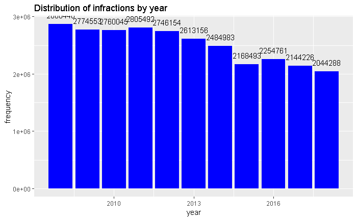

```r
#Visualizations  the Distribution of infractions by Year              3.3.1.ai
infractions_by_year
```

*3.3.1.aii The Distribution of all infractions by Month*

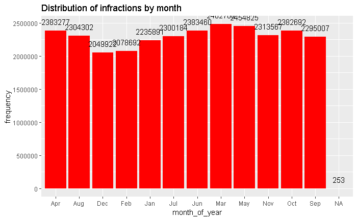

```r
#Visualizations  the Distribution of infractions by Month       3.3.1.aii
infractions_by_month
```

*3.3.1.b The Distribution of top 20 infractions by total ticket fines*

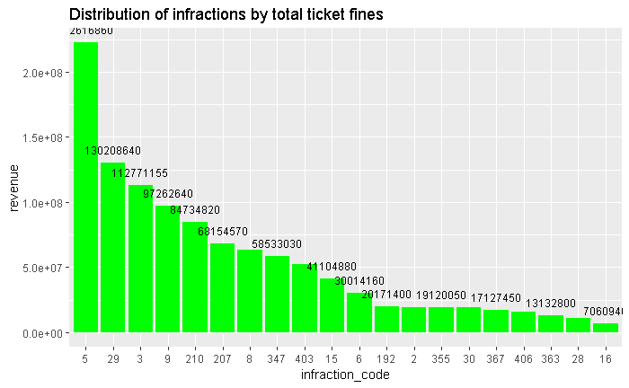

```r
# Distribution of top 20 infractions by total ticket fines     3.3.1b

infractions_by_fines
```

*3.3.2.a The Distribution of top 20 infractions Location*

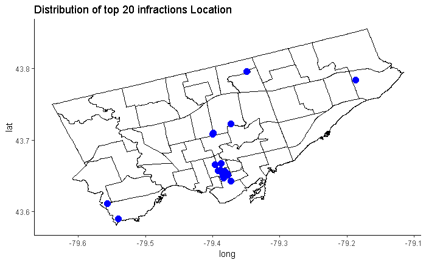

```r
#Distribution of top 20 infractions Location            3.3.2.a
Location
```

*3.3.2.b The Distribution of top 20 infractions count ward*

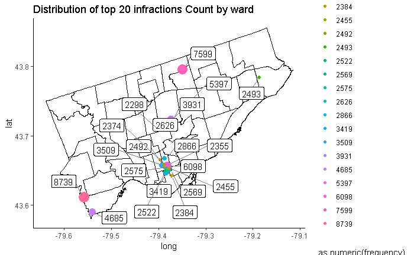

```r
#Distribution of top 20 infractions Count by ward               3.3.2b
Count_by_ward
```

*3.3.2.c The Distribution of top 20 infractions sum fines by ward*

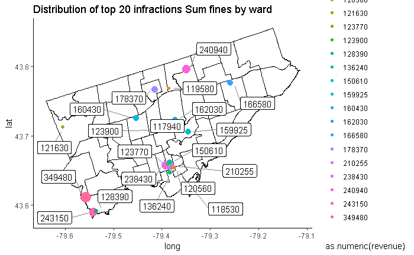

```r
#Distribution of top 20 infractions Sum fines by ward                           3.3.2c

Fines_by_ward
```